# Differential miRNA activity in TCGA tumors

Gabrielle Perron

2026-September-24

# 1 Load libraries

```r
library(tibble)
library(dplyr)
library(purrr)
library(glue)
library(stringr)
library(ggplot2)
library(tidyr)
library(SingleCellExperiment)
library(scater)
library(rsvd)
```

# 2 Cancer types to analyze

```r
# Extract cancer IDs from BETAS_ddf files
cancer_IDs <- list.files(here("data"), pattern = "^TCGA-.*\\.BETAS_ddf\\.csv$") |>
  sub("TCGA-", "", x = _) |>
  sub(".BETAS_ddf.csv", "", x = _)

cat("Cancer IDs found:", paste(cancer_IDs, collapse = ", "), "\n")
```

```
## Cancer IDs found: BLCA, BRCA, CHOL, COAD, ESCA, HNSC, KICH, KIRC, KIRP, LIHC, LUAD, LUSC, PRAD, READ, STAD, THCA, UCEC
```

# 3 Load the 3’UTR nucleotide composition and length annotations, and miRNA seed matches

```r
UTR_nt <- read.table(here("data", "3UTR_nt_composition_new.txt"), header = TRUE, row.names = NULL)
UTR_length <- read.table(here("data", "3UTR_length_new.txt"), header = TRUE, row.names = NULL)
miR_binding <- read.csv(here("data", "miRNA_seed_matches_3UTRs2000bp.csv"), header = TRUE)
```

# 4 Define miRNA name mapping

```r
mirna_name_mapping <- tibble(
  original = c(
    "let-7", "miR-101", "miR-10abc", "miR-122", "miR-124", "miR-127", "miR-133abc",
    "miR-135ab", "miR-136", "miR-138", "miR-141", "miR-143", "miR-145", "miR-146ac",
    "miR-150", "miR-153", "miR-155", "miR-15abc", "miR-17", "miR-182", "miR-184",
    "miR-185", "miR-187", "miR-18ab", "miR-191", "miR-193", "miR-194", "miR-196abc",
    "miR-199ab-5p", "miR-19ab", "miR-1ab", "miR-200bc", "miR-203", "miR-204",
    "miR-21", "miR-210", "miR-214", "miR-216a", "miR-216b", "miR-217", "miR-218",
    "miR-22", "miR-221", "miR-23abc", "miR-24", "miR-25", "miR-26ab", "miR-27abc",
    "miR-299", "miR-29abcd", "miR-300", "miR-30abcdef", "miR-31", "miR-326",
    "miR-328a", "miR-329", "miR-338", "miR-33ab", "miR-34ac", "miR-370", "miR-375",
    "miR-376abd", "miR-376c", "miR-377", "miR-383", "miR-433", "miR-448",
    "miR-450a", "miR-487b", "miR-495", "miR-496", "miR-504", "miR-505", "miR-539",
    "miR-543", "miR-544", "miR-551a", "miR-7", "miR-758", "miR-874", "miR-9",
    "miR-93", "miR-96", "miR-99ab", "miR.181abcd"
  ),
  canonical = c(
    "let-7-5p", "miR-101-3p", "miR-10-5p", "miR-122-5p", "miR-124-3p", "miR-127-3p",
    "miR-133-3p", "miR-135-5p", "miR-136-5p", "miR-138-5p", "miR-141-3p", "miR-143-3p",
    "miR-145-5p", "miR-146-5p", "miR-150-5p", "miR-153-3p", "miR-155-5p", "miR-15-5p",
    "miR-17-5p", "miR-182-5p", "miR-184", "miR-185-5p", "miR-187-3p", "miR-18-5p",
    "miR-191-5p", "miR-193-3p", "miR-194-5p", "miR-196-5p", "miR-199-5p", "miR-19-3p",
    "miR-1-3p", "miR-200bc-3p", "miR-203a-3p", "miR-204-5p", "miR-21-5p", "miR-210-3p",
    "miR-214-3p", "miR-216a-5p", "miR-216b-5p", "miR-217", "miR-218-5p", "miR-22-3p",
    "miR-221-3p", "miR-23-3p", "miR-24-3p", "miR-25-3p", "miR-26-5p", "miR-27-3p",
    "miR-299-3p", "miR-29-3p", "miR-381-3p", "miR-30-5p", "miR-31-5p", "miR-326",
    "miR-328-3p", "miR-329-3p", "miR-338-3p", "miR-33-5p", "miR-34-5p", "miR-370-3p",
    "miR-375", "miR-376-3p", "miR-376c-3p", "miR-377-3p", "miR-383-5p", "miR-433-3p",
    "miR-448", "miR-450-5p", "miR-487-3p", "miR-495-3p", "miR-496", "miR-4725-5p",
    "miR-505-3p", "miR-539-5p", "miR-543", "miR-544a-3p", "miR-551-3p", "miR-7-5p",
    "miR-758-3p", "miR-874-3p", "miR-9-5p", "miR-302-3p", "miR-96-5p", "miR-99-5p",
    "miR-181-5p"
  )
)
```

# 5 Define GLM fitting function

```r
fit_glm_sample <- function(glm_data, sample_name, cancer_ID) {
  # glm_data: complete data frame with response and all predictors
  # sample_name: name of the sample
  # cancer_ID: cancer type identifier
  sample_type <- ifelse(grepl("\\.01$", sample_name), "tumor", "normal")
  predictor_names <- names(glm_data)[
    names(glm_data) != "Gene_id" &
      !grepl("^TCGA\\.", names(glm_data))
  ]
  # Formula: response ~ confounders and miRNA affinity predictors
  # Intercept included automatically
  formula_str <- paste0(
    sample_name,
    " ~ ",
    paste(predictor_names, collapse = " + ")
  )

  fit <- glm(as.formula(formula_str), data = glm_data, na.action = na.exclude)
  coef_summary <- coef(summary(fit))

  # Extract coefficients and p-values for predictors only (miRNA cols, skip intercept and confounders)
  predictor_rows <- which(grepl("^(miR\\.|let\\.)", rownames(coef_summary)))

  tibble(
    miRNA = rownames(coef_summary)[predictor_rows],
    coefficient = coef_summary[predictor_rows, 1],
    pvalue = coef_summary[predictor_rows, 4],
    sample_name = sample_name,
    cancer_type = cancer_ID,
    sample_type = sample_type
  )
}
```

# 6 Process all cancer types, fit glm and correction for multiple testing

```r
stab_dir <- here("TCGA", "output", "supplementary_tables")

# Prepare 3'UTR annotations (constant across cancer types)
UTR <- merge(UTR_nt, UTR_length, by = 1)
UTR_miRNA <- merge(UTR, miR_binding, by = 1)

# Function to process a single cancer type
process_cancer_type <- function(cancer_ID) {
  cat("Processing cancer type:", cancer_ID, "\n")

  # Load stability data for this cancer type
  stab_file <- file.path(stab_dir, glue("TCGA-{cancer_ID}_stability_bias_corr.csv"))
  stability <- read.csv(stab_file)

  # Extract sample names and count tumor/normal samples
  sample_names <- colnames(stability)[-1]
  n_tumor <- sum(grepl("\\.01$", sample_names))
  n_normal <- sum(grepl("\\.11$", sample_names))

  # Merge stability with 3'UTR annotations
  glmMatrix <- merge(stability, UTR_miRNA, by = 1)
  colnames(glmMatrix)[1] <- "Gene_id"

  # Remove columns that are only NAs
  glmMatrix <- glmMatrix |>
    select(where(~ !all(is.na(.))))

  # Fit GLM for all samples in this cancer type and apply FDR correction
  glm_data <- map_dfr(
    colnames(stability)[-1],
    ~ fit_glm_sample(glmMatrix, .x, cancer_ID)
  ) |>
    mutate(FDR = p.adjust(pvalue, method = "fdr"))

  # Return both GLM results and sample counts
  list(
    glm_results = glm_data,
    sample_counts = tibble(cancer_ID = cancer_ID, n_tumor = n_tumor, n_normal = n_normal)
  )
}

# Apply to all cancer IDs and combine results
all_results <- map(cancer_IDs, process_cancer_type)
```

```
## Processing cancer type: BLCA
## Processing cancer type: BRCA
## Processing cancer type: CHOL
## Processing cancer type: COAD
## Processing cancer type: ESCA
## Processing cancer type: HNSC
## Processing cancer type: KICH
## Processing cancer type: KIRC
## Processing cancer type: KIRP
## Processing cancer type: LIHC
## Processing cancer type: LUAD
## Processing cancer type: LUSC
## Processing cancer type: PRAD
## Processing cancer type: READ
## Processing cancer type: STAD
## Processing cancer type: THCA
## Processing cancer type: UCEC
```

```r
# Extract GLM results and sample counts from the list
glm_results <- map_dfr(all_results, "glm_results")
sample_counts <- map_dfr(all_results, "sample_counts")
```

# 7 Sample counts table by cancer type

```r
sample_counts
```

```
## # A tibble: 17 × 3
##    cancer_ID n_tumor n_normal
##    <chr>       <int>    <int>
##  1 BLCA          406       19
##  2 BRCA         1089      113
##  3 CHOL           36        9
##  4 COAD          455       41
##  5 ESCA          159        9
##  6 HNSC          498       44
##  7 KICH           60       16
##  8 KIRC          527       72
##  9 KIRP          284       32
## 10 LIHC          371       50
## 11 LUAD          513       59
## 12 LUSC          439       27
## 13 PRAD          493       52
## 14 READ          166       10
## 15 STAD          371       31
## 16 THCA          497       58
## 17 UCEC          539       35
```

```r
sum(sample_counts$n_tumor)
```

```
## [1] 6903
```

```r
sum(sample_counts$n_normal)
```

```
## [1] 677
```

```r
length(sample_counts$cancer_ID)
```

```
## [1] 17
```

# 8 Convert inferred target stability effects into miRNA activity estimates by reversing the coefficient sign, express coefficients on a log2 scale

```r
glm_results <- glm_results |>
  mutate(
    coefficient = -coefficient,
    coefficient_log2 = log2(exp(coefficient))
  )

head(glm_results)
```

```
## # A tibble: 6 × 8
##   miRNA     coefficient  pvalue sample_name     cancer_type sample_type   FDR
##   <chr>           <dbl>   <dbl> <chr>           <chr>       <chr>       <dbl>
## 1 let.7        -0.0524  0.00520 TCGA.2F.A9KO.01 BLCA        tumor       0.310
## 2 miR.101      -0.0146  0.393   TCGA.2F.A9KO.01 BLCA        tumor       0.874
## 3 miR.103a     -0.00259 0.860   TCGA.2F.A9KO.01 BLCA        tumor       0.980
## 4 miR.10abc    -0.0213  0.227   TCGA.2F.A9KO.01 BLCA        tumor       0.800
## 5 miR.122       0.0302  0.113   TCGA.2F.A9KO.01 BLCA        tumor       0.699
## 6 miR.124       0.00203 0.877   TCGA.2F.A9KO.01 BLCA        tumor       0.982
## # ℹ 1 more variable: coefficient_log2 <dbl>
```

# 9 Reformat miRNA names

```r
glm_results$miRNA <- gsub("\\.[A-Z].*", "", glm_results$miRNA)
glm_results$miRNA <- gsub("_.*", "", glm_results$miRNA)
glm_results$miRNA <- gsub("\\.", "-", glm_results$miRNA)

glm_results <- glm_results |>
  left_join(mirna_name_mapping, by = c("miRNA" = "original")) |>
  mutate(miRNA = coalesce(canonical, miRNA)) |>
  select(-canonical)
```

# 10 Compute signed log10(p-values)

Multiply log10(p-value) by the sign of the coefficient to indicate direction of miRNA activity:

```r
glm_results <- glm_results |>
  mutate(
    signed_logP = sign(coefficient) * (-log10(pvalue))
  )
```

# 11 Save results

```r
# Save all results in long-format tibble
write.csv(glm_results, file = here("TCGA", "output", "supplementary_tables", "TCGA_miRNA_activity.csv"), row.names = FALSE)
```

# 12 Number of miRNAs with dysregulated activity in at least one tumor sample

```r
glm_results %>%
  filter(grepl("\\.01$", sample_name)) %>%   # Keep only primary tumor samples
  filter(!is.na(FDR), FDR < 0.05) %>%
  pull(miRNA) %>%
  unique() %>%
  length()
```

```
## [1] 91
```

# 13 Determine the miRNAs that have significant changes in activity in at least 10 tumor samples for each cancer type

```r
sig_miRNAs <- glm_results %>%
  filter(grepl("\\.01$", sample_name)) %>%   # Keep only primary tumor samples
  filter(FDR < 0.05) %>%
  group_by(cancer_type, miRNA) %>%
  summarise(
    n_samples = n_distinct(sample_name),
    median_coefficient = median(coefficient, na.rm = TRUE),
    .groups = "drop"
  ) %>%
  filter(n_samples >= 10) %>%
  arrange(cancer_type, desc(n_samples))

sig_miRNAs
```

```
## # A tibble: 53 × 4
##    cancer_type miRNA        n_samples median_coefficient
##    <chr>       <chr>            <int>              <dbl>
##  1 BLCA        miR-29-3p          162            -0.0731
##  2 BLCA        miR-200bc-3p        20             0.0574
##  3 BLCA        let-7-5p            11            -0.0972
##  4 BRCA        miR-29-3p          420            -0.0588
##  5 BRCA        miR-26-5p           73            -0.0699
##  6 BRCA        miR-200bc-3p        69             0.0522
##  7 BRCA        miR-143-3p          25            -0.0568
##  8 BRCA        miR-19-3p           19             0.0791
##  9 BRCA        let-7-5p            15            -0.0915
## 10 BRCA        miR-21-5p           14             0.0730
## # ℹ 43 more rows
```

```r
# Save
write.csv(sig_miRNAs, here("TCGA", "output", "supplementary_tables", "TCGA_sig_mirs_atleast10Tsamples_allCancers.csv"), row.names = F)
```

# 14 % of colon adenocarcinomas (COAD) that show a significant increase in miR-19-3p activity

```r
glm_results %>%
  filter(
    cancer_type == "COAD",
    miRNA == "miR-19-3p",
    sample_type == "tumor"
  ) %>%
  summarise(
    percent = 100 * mean(FDR < 0.05 & coefficient > 0)
  ) %>%
  pull(percent)
```

```
## [1] 20.21978
```

# 15 % of clear cell renal cell carcinomas (KIRC) that show decreased activity of miR-30-5p

```r
glm_results %>%
  filter(
    cancer_type == "KIRC",
    miRNA == "miR-30-5p",
    sample_type == "tumor"
  ) %>%
  summarise(
    percent = 100 * mean(FDR < 0.05 & coefficient < 0)
  ) %>%
  pull(percent)
```

```
## [1] 82.73245
```

# 16 % of liver hepatocellular carcinoma (LIHC) and cholangiocarcinoma (CHOL) tumors that show reduced activity of miR-122-5p

```r
glm_results %>%
  filter(
    cancer_type == "LIHC",
    miRNA == "miR-122-5p",
    sample_type == "tumor"
  ) %>%
  summarise(
    percent = 100 * mean(FDR < 0.05 & coefficient < 0)
  ) %>%
  pull(percent)
```

```
## [1] 15.90296
```

```r
glm_results %>%
  filter(
    cancer_type == "CHOL",
    miRNA == "miR-122-5p",
    sample_type == "tumor"
  ) %>%
  summarise(
    percent = 100 * mean(FDR < 0.05 & coefficient < 0)
  ) %>%
  pull(percent)
```

```
## [1] 97.22222
```

# 17 Visualizing significantly dysregulated miRNAs

For each cancer type and miRNA, determine the sqrt(% of tumor samples where the miRNA is upregulated), and same for downregulated.

We use sqrt(%), to get the circle area, proportional to the percentage, for making the heatmap.

```r
htmp_table <- glm_results %>%
  # Filter for tumor samples ending in '.01'
  filter(str_detect(sample_name, "\\.01$")) %>%

  # Group by cancer type and miRNA
  group_by(cancer_type, miRNA) %>%

  # Calculate percentage of upregulated and downregulated samples
  summarise(
    sqrt_percent_down = sqrt((sum(FDR < 0.05 & coefficient < 0) / n()) * 100),
    sqrt_percent_up   = sqrt((sum(FDR < 0.05 & coefficient > 0) / n()) * 100),
    .groups = "drop"
  )
```

Remove miRNAs with only 0s in all cancer types and for both up and downregulation

```r
dim(htmp_table)
```

```
## [1] 2601    4
```

```r
htmp_table <- htmp_table %>%
  group_by(miRNA) %>%
  filter(any(sqrt_percent_down > 0 | sqrt_percent_up > 0)) %>%
  ungroup()
dim(htmp_table)
```

```
## [1] 1547    4
```

Get the data after clustering based on the sqrt(%) of samples where the miRNAs are downregulated

```r
# Create matrix for clustering
down_mat <- htmp_table |>
  select(miRNA, cancer_type, sqrt_percent_down) |>
  pivot_wider(
    names_from = cancer_type,
    values_from = sqrt_percent_down,
    values_fill = 0
  )

# extract matrix
clust_mat <- down_mat |>
  column_to_rownames("miRNA") |>
  as.matrix()

# hierarchical clustering
hc <- hclust(dist(clust_mat), method = "ward.D2")

# ordered miRNAs
mirna_order <- hc$labels[hc$order]
```

```r
# Prepare data for plotting: pivot to wide format, apply clustering order, and return to long format
plot_data <- htmp_table |>
  pivot_longer(
    cols = starts_with("sqrt_percent"),
    names_to = "direction",
    values_to = "sqrt_percent"
  ) |>
  mutate(
    direction = recode(direction,
      "sqrt_percent_down" = "down",
      "sqrt_percent_up" = "up"
    ),
    miRNA = factor(miRNA, levels = mirna_order, ordered = TRUE)
  ) |>
  arrange(miRNA)

# Apply a minimum threshold to very small non-zero values
min_threshold <- 1
plot_data <- plot_data |>
  mutate(sqrt_percent = ifelse(
    sqrt_percent > 0 & sqrt_percent < min_threshold,
    min_threshold,
    sqrt_percent
  ))

# Create plots for up and down regulation
create_dot_heatmap <- function(data, direction_val, color) {
  size_limits <- c(0, 10)
  data_filtered <- data |> filter(direction == direction_val)

  # Create legend with clean percentage breaks (0, 25, 50, 75, 100%)
  percent_breaks <- c(0, 25, 50, 75, 100)
  sqrt_breaks <- sqrt(percent_breaks)
  legend_labels <- paste0(percent_breaks, "%")

  ggplot(data_filtered) +
    geom_point(aes(
      x = cancer_type,
      y = miRNA,
      size = sqrt_percent,
      color = ifelse(sqrt_percent > 0, color, NA)
    ), na.rm = TRUE) +
    scale_color_identity(guide = "none") +
    scale_size_continuous(
      name = paste0("% samples with significant\nmiRNA activity ", direction_val, "regulation"),
      range = c(0.1, 8),
      breaks = sqrt_breaks,
      labels = legend_labels,
      limits = size_limits
    ) +
    labs(x = "", y = "") +
    theme_classic() +
    theme(
      axis.text.x = element_text(angle = 90, hjust = 1, vjust = 0.5, size = 12),
      axis.text.y = element_text(size = 8),
      text = element_text(size = 12),
      legend.key.size = unit(1.5, "lines"),
      panel.background = element_rect(fill = "white", colour = "white"),
      plot.margin = unit(c(1, 1, 1, 1), "cm")
    )
}

# Create and save plots
p_up <- create_dot_heatmap(plot_data, "up", "red")
pdf(here("TCGA", "output", "figures", "TCGA_percent_tumors_sig_up_mirs_dotplot.pdf"),
    width = 9.5, height = 15)
print(p_up)
dev.off()
```

```r
p_down <- create_dot_heatmap(plot_data, "down", "blue")
pdf(here("TCGA", "output", "figures", "TCGA_percent_tumors_sig_down_mirs_dotplot.pdf"),
    width = 9.5, height = 15)
print(p_down)
dev.off()
```

# 18 Pan-cancer miRNA activity illustrated using t-SNE plots

Theme function for t-SNE plots

```r
custom_theme_plot <- function(size_text=15,
                              leg_pos="right",
                              size_text_titles=NULL,
                              classic=TRUE,
                              line_size=0.85,
                              line_size_color="black",
                              axis_ticks_length=0.25,
                              axis_ticks_color="black",
                              size_legend_text=12,
                              size_legend_title=14
                              ){
    require(ggplot2)
    if( is.null(size_text_titles) ){
        size_text_titles<- size_text + 2
    }
    if( classic ){
        gg.plots<- theme_classic()
    }else{
        gg.plots<- theme_bw()
    }
    gg.plots <- gg.plots +
        theme(axis.text.x=element_text(size=size_text, angle=45, hjust=1, color=line_size_color),
              axis.line=element_line(size=line_size, colour=line_size_color),
              axis.ticks=element_line(colour=axis_ticks_color, size=line_size),
              axis.ticks.length=unit(axis_ticks_length, "cm"),
              axis.title.x=element_text(size=size_text_titles),
              legend.position=leg_pos,
              plot.title=element_text(hjust=0.5, size=size_text),
              axis.text.y=element_text(size=size_text, color="black"),
              axis.title.y=element_text(size=size_text_titles),
              legend.text=element_text(size=size_legend_text),
              legend.title=element_text(size=size_legend_title),
              legend.key.size=unit(0.8, "cm") )
}
```

Prepare data for t-SNE visualization

```r
# Create a wide matrix: samples as rows, miRNAs as columns
# Filter to tumor samples only and miRNAs with at least one significant hit
glm_tumor <- glm_results |>
  filter(grepl("\\.01$", sample_name))

# Create matrices for coefficient and FDR values
coeff_wide <- glm_tumor |>
  select(sample_name, miRNA, coefficient) |>
  pivot_wider(
    names_from = miRNA,
    values_from = coefficient,
    values_fill = NA
  ) |>
  column_to_rownames("sample_name") |>
  as.matrix()

fdr_wide <- glm_tumor |>
  select(sample_name, miRNA, FDR) |>
  pivot_wider(
    names_from = miRNA,
    values_from = FDR,
    values_fill = NA
  ) |>
  column_to_rownames("sample_name") |>
  as.matrix()

signed_logp_wide <- glm_tumor |>
  select(sample_name, miRNA, signed_logP) |>
  pivot_wider(
    names_from = miRNA,
    values_from = signed_logP,
    values_fill = NA
  ) |>
  column_to_rownames("sample_name") |>
  as.matrix()

# Get cancer type for each sample
cancer_type <- glm_tumor |>
  distinct(sample_name, cancer_type) |>
  tibble::column_to_rownames("sample_name") |>
  {\(x) setNames(x$cancer_type, rownames(x))}()

# Keep samples and miRNAs with at least one significant hit (FDR < 0.05)
rows_keep <- which(rowSums(fdr_wide < 0.05, na.rm = TRUE) > 0)
cols_keep <- which(colSums(fdr_wide < 0.05, na.rm = TRUE) > 0)

signed_logp_flt <- signed_logp_wide[rows_keep, cols_keep]
coeff_flt <- coeff_wide[rows_keep, cols_keep]
fdr_flt <- fdr_wide[rows_keep, cols_keep]

# Filter cancer type vector to match filtered samples
cancer_type_flt <- cancer_type[rownames(coeff_flt)]

# Prepare data for SingleCellExperiment
# Use coefficients as the expression data (samples become columns after transpose)
dt <- data.matrix(t(coeff_flt))

# Select miRNAs for coldata
mir_cols <- c("miR-17-5p", "miR-29-3p", "miR-30-5p", "miR-19-3p", "miR-122-5p")
mir_cols_present <- mir_cols[mir_cols %in% colnames(coeff_flt)]

# Build coldata
coldata <- data.frame(
  sample = colnames(dt),
  cancer = cancer_type_flt,
  stringsAsFactors = FALSE
)

# Add miRNA activity columns
for (mir in mir_cols_present) {
  coldata[[mir]] <- as.numeric(signed_logp_flt[coldata$sample, mir])
}
```

Create SingleCellExperiment object and compute t-SNE

```r
sce <- SingleCellExperiment(list(logcounts = dt), colData = coldata)
sce
```

```
## class: SingleCellExperiment
## dim: 91 3162
## metadata(0):
## assays(1): logcounts
## rownames(91): let-7-5p miR-101-3p ... miR-615-3p miR-874-3p
## rowData names(0):
## colnames(3162): TCGA.2F.A9KO.01 TCGA.2F.A9KP.01 ... TCGA.QS.A744.01
##   TCGA.SJ.A6ZI.01
## colData names(7): sample cancer ... miR-19-3p miR-122-5p
## reducedDimNames(0):
## mainExpName: NULL
## altExpNames(0):
```

```r
# Set seed for reproducibility
set.seed(5431)
sce_pca <- rpca(t(assay(sce, "logcounts")), k = 100)
reducedDim(sce, "pca") <- sce_pca$x

# Run t-SNE
# sce_tSNE <- scater::runTSNE(sce, dimred = "pca", perplexity = 50)
# saveRDS(sce_tSNE, here("TCGA", "output", "rds", "sce_tSNE.rds")) # This caused issues when knitting
sce_tSNE <- readRDS(here("TCGA", "output", "rds", "sce_tSNE.rds"))

# Set color limits
lims <- 2

# Print dim
dim(sce_tSNE)
```

```
## [1]   91 3162
```

Plot t-SNE colored by cancer type

[figure not shown]

```r
plotReducedDim(sce_tSNE,
               ncomponents = 2,
               dimred = "TSNE",
               point_size = 2,
               colour_by = "cancer") +
      custom_theme_plot(size_text = 27, size_text_titles = 30, size_legend_text = 21, size_legend_title = 24) +
      labs(colour = "Cancer type") +
      guides(colour = guide_legend(override.aes = list(size = 8), keyheight = 0.8, keywidth = 0.8)) +
      theme(legend.spacing.y = unit(-0.3, "cm"))
```

```r
pdf(here("TCGA", "output", "figures", "TCGA_pancancer_miR_act_tSNE_cancer.pdf"),
    height = 10, width = 10)
plotReducedDim(sce_tSNE,
               ncomponents = 2,
               dimred = "TSNE",
               point_size = 2,
               colour_by = "cancer") +
      custom_theme_plot(size_text = 27, size_text_titles = 30, size_legend_text = 21, size_legend_title = 24) +
      labs(colour = "Cancer type") +
      guides(colour = guide_legend(override.aes = list(size = 8), keyheight = 0.8, keywidth = 0.8)) +
      theme(legend.spacing.y = unit(-0.3, "cm"))
dev.off()
```

Helper function to create t-SNE plots for individual miRNAs

```r
create_mir_tsne_plot <- function(mir_name, sce_obj, limits = 2) {
  plotReducedDim(sce_obj,
                 ncomponents = 2,
                 dimred = "TSNE",
                 point_size = 2,
                 colour_by = mir_name) +
    custom_theme_plot(size_text = 27, size_text_titles = 30, size_legend_text = 21, size_legend_title = 24) +
    scale_colour_gradient2(
      low = "blue", high = "red", mid = "white",
      midpoint = 0, limits = c(-limits, limits),
      oob = scales::squish,
      name = "miRNA activity\nsigned log10(p-value)"
    ) +
    theme(legend.key.size = unit(1.2, "cm"))
}
```

Plot t-SNE for individual miRNAs

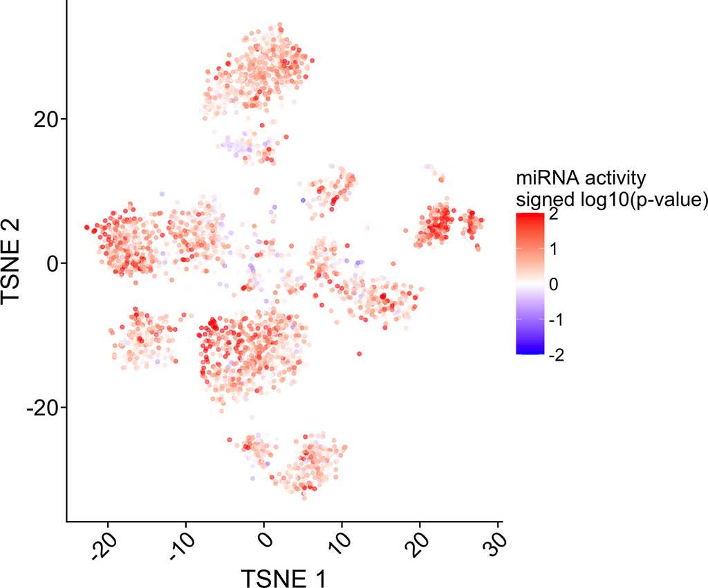

```
## Saved: TCGA_pancancer_miR_act_tSNE_miR17.pdf
```

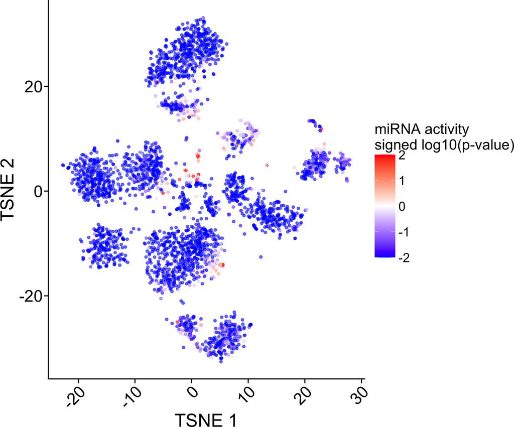

```
## Saved: TCGA_pancancer_miR_act_tSNE_miR29.pdf
```

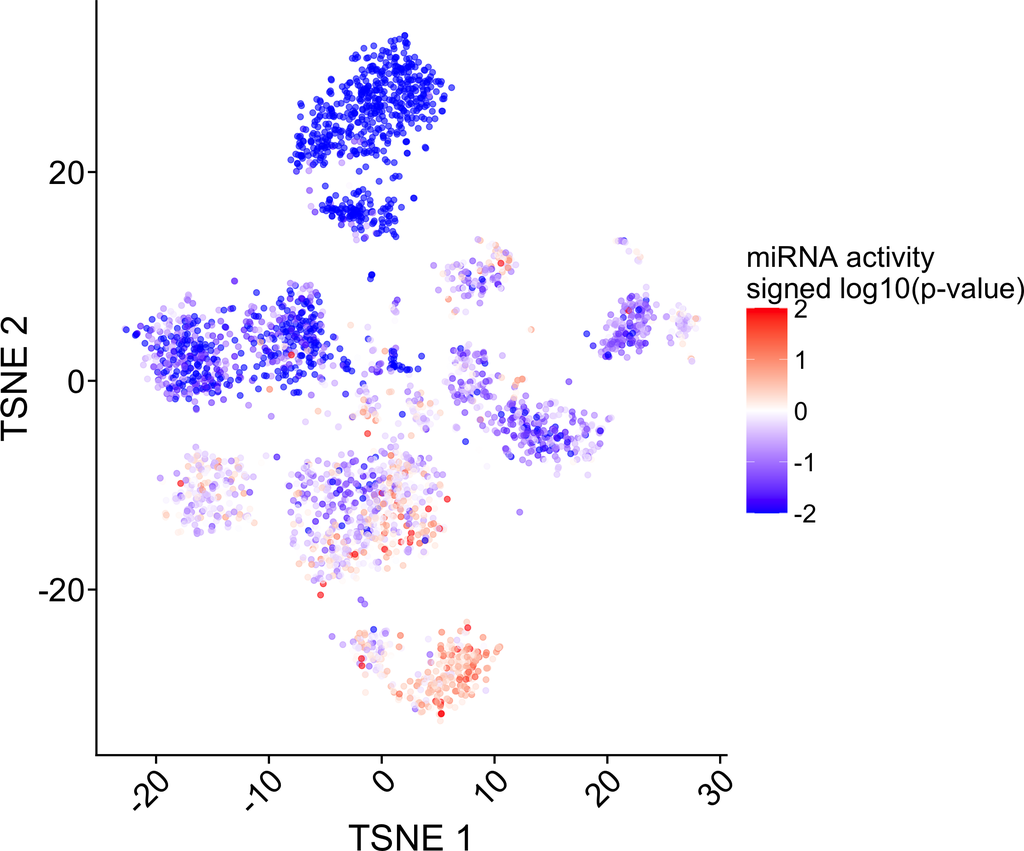

```
## Saved: TCGA_pancancer_miR_act_tSNE_miR30.pdf
```

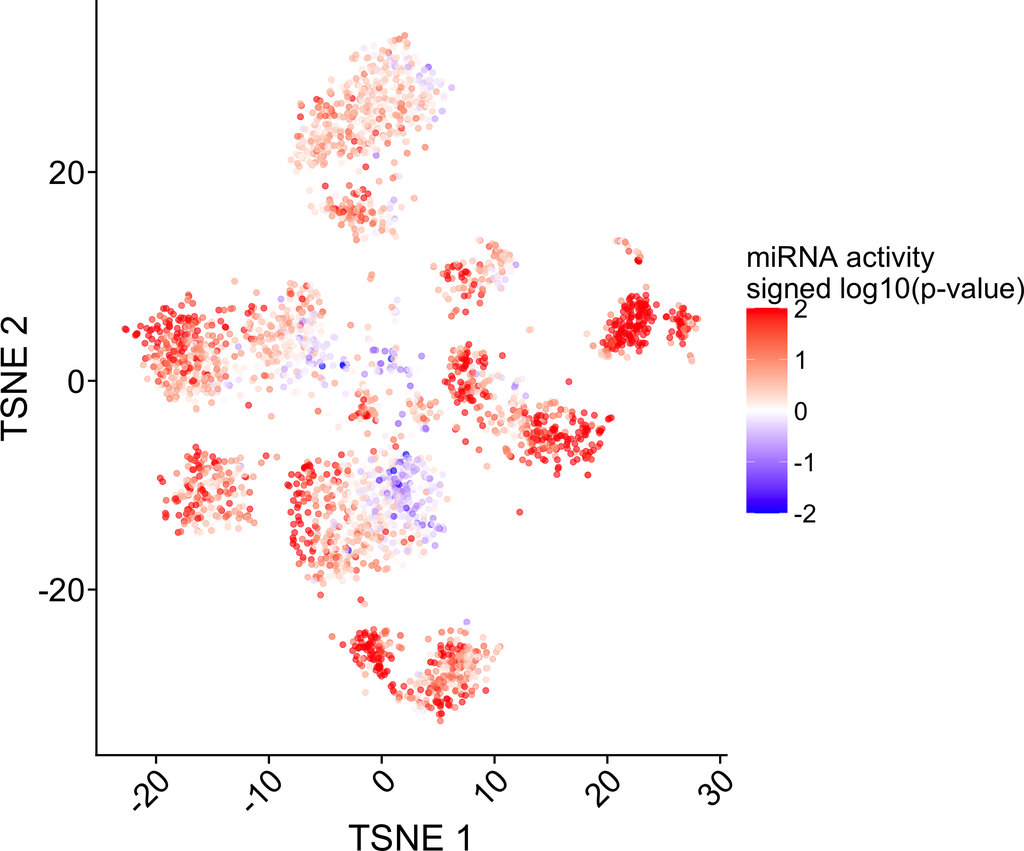

```
## Saved: TCGA_pancancer_miR_act_tSNE_miR19.pdf
```

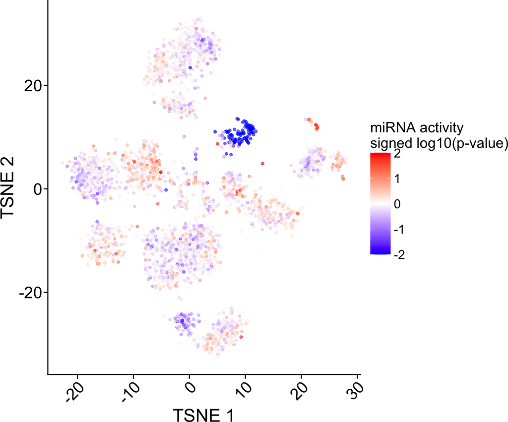

```
## Saved: TCGA_pancancer_miR_act_tSNE_miR122.pdf
```

```r
# List of miRNAs to visualize
mir_list <- list(
  "miR-17-5p" = "TCGA_pancancer_miR_act_tSNE_miR17.pdf",
  "miR-29-3p" = "TCGA_pancancer_miR_act_tSNE_miR29.pdf",
  "miR-30-5p" = "TCGA_pancancer_miR_act_tSNE_miR30.pdf",
  "miR-19-3p" = "TCGA_pancancer_miR_act_tSNE_miR19.pdf",
  "miR-122-5p" = "TCGA_pancancer_miR_act_tSNE_miR122.pdf"
)

# Create plots for each miRNA
for (mir_name in names(mir_list)) {
  # Only create if miRNA is present in the data
  if (mir_name %in% colnames(coldata)) {
    # Display plot
    print(create_mir_tsne_plot(mir_name, sce_tSNE, limits = lims))

    # Save to PDF
    pdf_file <- here("TCGA", "output", "figures", mir_list[[mir_name]])
    pdf(pdf_file, height = 10, width = 12)
    print(create_mir_tsne_plot(mir_name, sce_tSNE, limits = lims))
    dev.off()

    cat("Saved:", mir_list[[mir_name]], "\n")
  }
}
```